# Initial Analyses of Climatological Time-Series

Manon von Kaenel & Nick Depsky

August 5th 2016

**Intro:** Some notes for filtering, exploring, and conducting some basic statistical analyses on raw climate data from local station observations using R. This script was originally written in the context of preparing climate input data for a WEAP model, and is a good initial step in this process. The script was prepared by the Stockholm Environment Institute (SEI) Water Group (see SEI Water Group’s github page [here](https://seiwater.github.io/)).

**Access to raw data and Rmarkdown files:** The Rmarkdown file used to generate this page is stored on github, [here](https://github.com/seiwater/seiwater.github.io/tree/master/R). The example data/files used in this script is also stored on github, [here](https://github.com/seiwater/Raw-Data/raw/master/rawclimatedataR.zip).

**Last Updated:** Manon von Kaenel, Sept 26th 2016

## Goals

Go over some common workflows relevant to exploring, filtering, and correcting climate station data. The goals of these initial analyses of climatological time-series are to familiarize yourself with your climate data; specifically, to:

- Understand the **spatial distribution** of your climate stations
- Understand the **temporal distribution** of the observed climate measurements
- Understand the **statistical variability** of the observed climate measurements

The knowledge and understanding generated by these analyses can inform the following workflows:

- Subsetting data to designated period of record and selected stations
- Identifying and removing incorrect and extreme data values
- [Filling in missing data](https://seiwater.github.io/2016/09/15/Filling-Missing-Data-in-Climatological-Time-Series.html)

This example will use precipitation and temperature records from stations in the Chancay Lambayeque watershed, Peru.

## Resources

Data used for the examples are hosted on github, [here](https://github.com/seiwater/Raw-Data/raw/master/rawclimatedataR.zip). The zipped file contains the following…

- Table-All-Precip.csv: a csv of daily precipitation data (unfiltered) from climate stations in and surrounding the Chancay-Lambayeque watershed, Peru
- Table-All-Temp-Max.csv: a csv of daily maximum temperature data (unfiltered) from same stations
- Table-All-Temp-Min.csv: a csv of daily minimum temperature data (unfiltered) from same stations
- Coordinates.csv: a csv of lat-long coordinates of local climate stations
- Proyecto CuencaCL.shp: a shapefile (including related files) of study site extent

You can download/unzip the data by hand or run the following code to download and unzip the data to a temporary directory.

```r
setwd(tempdir())  # set working directory to temporary directory
dir <- getwd()

download.file("https://github.com/seiwater/Raw-Data/raw/master/rawclimatedataR.zip", destfile = 'rawclimatedataR.zip')

unzip( 'rawclimatedataR.zip' , exdir = dir)
```

# 0. Prerequisites

Some functions we will use come the following packages, so be sure to have them installed prior to attempting this exercise:

- ggplot2 for graphing functions
- raster for managing shapefiles
- rgdal for opening shapefiles

You can download these packages with…

```r
install.packages('ggplot2', repos = "http://cran.cnr.berkeley.edu/",lib=dir)
install.packages('rgdal',repos="http://cran.cnr.berkeley.edu/",lib=dir, type="source")
install.packages('raster', repos = "http://cran.cnr.berkeley.edu/",type="source",lib=dir)

library(ggplot2)
library(rgdal)
library(raster)
```

# 1. Get the data in

First, let’s get all the data you’ll need for this script loaded into your working directory.

```r
setwd(dir)
Precip <- read.csv('Table_All_Precip.csv', check.names = F, stringsAsFactors = F)
Temp_Min <- read.csv('Table_All_Temp_Min.csv', check.names = F, stringsAsFactors = F)
Temp_Max <- read.csv('Table_All_Temp_Max.csv', check.names = F, stringsAsFactors = F)
Coordinates <- read.csv('Coordinates.csv', check.names = F, stringsAsFactors = F)
project <- readOGR(dir,'Proyecto_CuencaCL')
```

That was easy!

As a side note, the ‘check.names = F’ parameter in the ‘read.csv’ function preserves the column headers from the original record table.

Your input climate tables should look like this (in this case, the first couple months on record have missing data for the stations displayed here):

```r
head(Precip[,1:7])
```

```
##     Anio Mes Dia ASUNCION Augusto Weberbauer AYLAMBO
## 1 1 1960   1   1       NA                 NA      NA
## 2 2 1960   1   2       NA                 NA      NA
## 3 3 1960   1   3       NA                 NA      NA
## 4 4 1960   1   4       NA                 NA      NA
## 5 5 1960   1   5       NA                 NA      NA
## 6 6 1960   1   6       NA                 NA      NA
```

Note that the first three columns correspond to date information: year, month, and day. The script runs with R date objects, so we will be converting these three columns to dates later. Your data may have a different format for dates; regardless, this script runs with date objects (in the form of YYYY-MM-DD). Also, note that the example data is in daily format; however, the script should also work for monthly data.

And the coordinate table should look like this, with spatial information saved in lat and long coordinates:

```r
head(Coordinates)
```

```
##                Station Longitude  Latitude
## 1 1           ASUNCION -78.51550 -7.312100
## 2 2 Augusto Weberbauer -78.48480 -7.166611
## 3 3            AYLAMBO -78.52528 -7.186389
## 4 4         BAMBAMARCA -78.52528 -6.677500
## 5 5           CACHACHI -78.27111 -7.457500
## 6 6          CAJABAMBA -78.05056 -7.626944
```

# 2. Temporal Distribution

Let’s first look at the **temporal** distribution of your data; that is, the period of record for each climate variable at each station. This will help us assess the amount of missing data we are dealing with, and designate an optimal period of record for your project.

## Plot a Period of Record Graph

This first chunk of script opens up a path in your working directory to save a PDF of the resulting period of record graph.

```r
filename <- "Period of Record"
plotpath <- c(dir, "\\",filename, ".pdf") # USER-DEFINED creates a pdf path to produce a graphic of the span of records in the Table_All
plotpath <- paste(plotpath, collapse = '')
pdf(file = plotpath) # opens connection to pdf path
par(mfrow=c(1,1)) # parameter that dictates how many rows and columns of graphics to be present in the output pdf. (1,1) implies one graphic per page, in this case there is only 1.
```

Next, we want to make sure we have a column corresponding to the date at which each measurement is taken. In this case, we want to combine the “year”, “month”, and “day” columns. We will use the Precipitation data as our first example here.

```r
Table_All <- Precip # designate which climate table you want to be working on here.

date1 <- paste(c(Table_All[1,2],"/",Table_All[1,3],"/",Table_All[1,4]),collapse="") # create date object of first row of data
date2 <- paste(c(Table_All[nrow(Table_All),2],"/",Table_All[nrow(Table_All),3],"/",Table_All[nrow(Table_All),4]),collapse="") # create date object of last row of data
years <- seq(as.Date(date1),as.Date(date2),"days") # create date sequence for entire series
Table_All[,1] <- NULL # deletes unnecessary columns
Table_All[,1] <- NULL
Table_All[,1] <- NULL
Table_All[,1] <- NULL
Table_All <- cbind(years,Table_All) # adds date column
```

This is how your table should look like now (showing the first couple columns & rows). Note the date column (“years”).:

```
##        years ASUNCION Augusto Weberbauer AYLAMBO BAMBAMARCA
## 1 1960-01-01       NA                 NA      NA         NA
## 2 1960-01-02       NA                 NA      NA         NA
## 3 1960-01-03       NA                 NA      NA         NA
## 4 1960-01-04       NA                 NA      NA         NA
## 5 1960-01-05       NA                 NA      NA         NA
## 6 1960-01-06       NA                 NA      NA         NA
```

Next, let’s create a Record Table, which will contain information as to the presence/absence of a data point at each timestep for each station.

```r
stations <- colnames(Table_All[,2:ncol(Table_All)])
Record_Table <- !is.na(Table_All)
Record_Table[Record_Table == TRUE] <- 1
Record_Table[Record_Table == 0] <- NA
```

Finally, let’s plot the period of record for each station.

Let’s see the resulting plot. Note that this plot doesn’t contain any information about the observations themselves; instead, it simply plots the existence of data at each timestep with a blue line. Gaps in the lines thus indicate missing data. The stations are labeled and stacked on the y-axis.

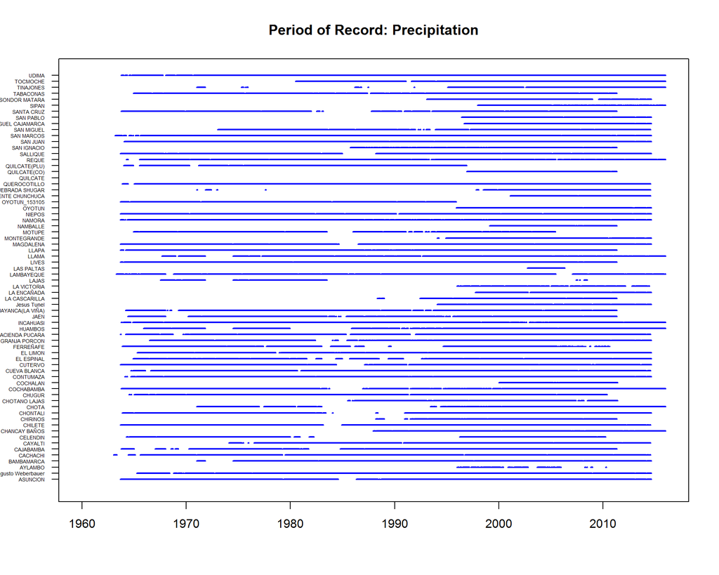

We’ll repeat the process to see the period of record for minimum temperature at each station….

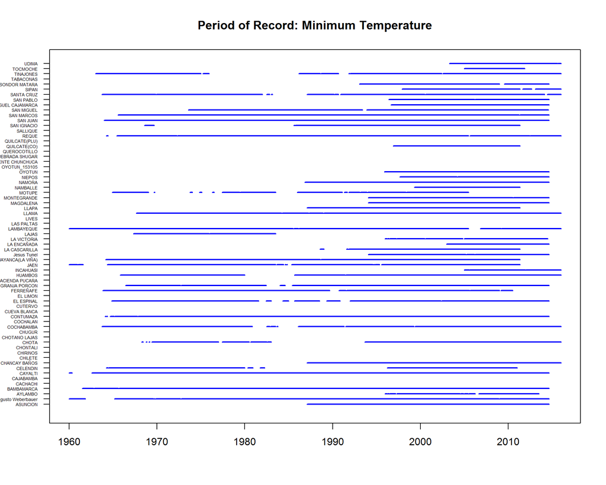

… and for maximum temperature.

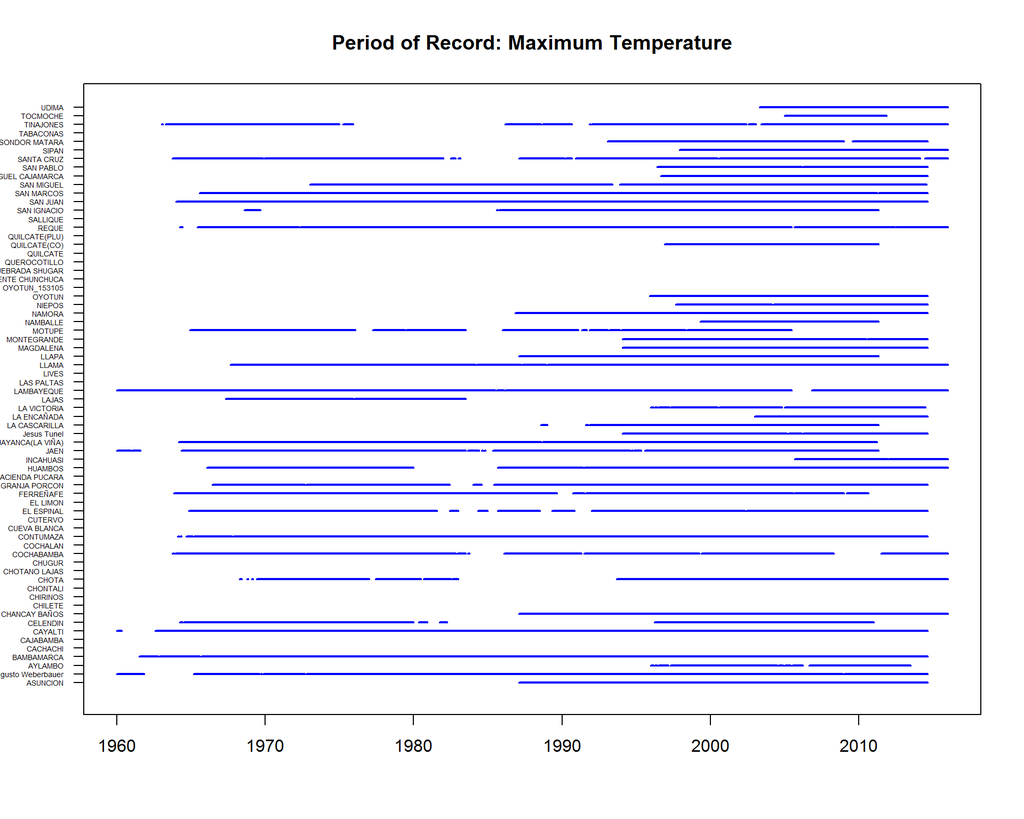

# 3. Spatial Distribution

Now, let’s take a look at how the stations are **spatially distributed** within your study site, and explore which stations have precipitation and/or temperature data available within any designated period of record. This will help us assess the availability of data in a spatial sense, again informing what an optimal period of record may be, and helping to inform us about any holes in data that may affect future workflows and analyses.

## Create a Station Map

First, let’s define the longitude and latitude of your study site, the zoom level at which you want to see the base map, and the title of you map.

```r
lon_project <- -79.25 # USER-DEFINED: longitude of project (for map)
lat_project <- -6.75 # USER-DEFINED: latitude of project (for map)
zoom_map <- 8 # USER-DEFINED: zoom for satellite map
map_title <- "Climate Stations Chancay Lambayeque" # title of map
```

Now, let’s use the ggmap and ggplot2 packages to plot the locations of your climate stations, color-coded by what kind of climate data each one has, on a base map of nice satellite imagery. We will use the shapefile of the study site that we loaded in at the beginning of this script.

```r
stations_temp <- sub("\\.","", sub("\\.", " ", sub("\\.", " ", colnames(Temp_Min[5:ncol(Temp_Min)])))) # NOTE: this step is to eliminate any weird characters in the station names from the precip and temp data tables; may be different for your project!!!
stations_precip <- sub("\\.","", sub("\\.", " ", sub("\\.", " ", colnames(Precip[5:ncol(Precip)])))) # NOTE: this step is to eliminate any weird characters in the station names from the precip and temp data tables; may be different for your project!!!

coordinates_temp <- Coordinates[Coordinates[,2] %in% stations_temp,] ## Coordinates for stations from which we are using temp data
coordinates_precip <-  Coordinates[Coordinates[,2] %in% stations_precip,] ## Coordinates for stations from which we are using precip data
```

[figure not shown]

```r
install.packages("ggmap", repos = "http://cran.cnr.berkeley.edu/") # make sure you have ggmap installed for use of its mapping functions
library(ggmap)

maptest <- get_map(location=c(lon=lon_project, lat=lat_project), zoom = zoom_map, maptype="satellite",scale=2, source="google",filename="maptest", force = ifelse(source == "google", TRUE, TRUE)) # saves a google map of your project area

ggmap(maptest) + # plots the backgound map
  geom_polygon(aes(x=long, y=lat),size=1,colour='black',data=project,alpha=0) + # plots the polygon of your project area
  geom_text(data = Coordinates, aes(x = Coordinates[,"Longitude"], y = Coordinates[,"Latitude"], label = Coordinates[,"Station"]),
            size = 1.5, vjust = 0, hjust = -0.2, color="light grey") + # plots the names of all the stations
  geom_point(data = as.data.frame(Coordinates), aes(x=as.numeric(Coordinates[,"Longitude"]), y=as.numeric(Coordinates[,"Latitude"])),colour='black',size=3.5,shape=1) + # plots all the stations in black circles
  geom_point(data = as.data.frame(coordinates_precip), aes(x=as.numeric(coordinates_precip[,"Longitude"]), y=as.numeric(coordinates_precip[,"Latitude"])),colour='blue',size=1.5,shape=6) + # plots the precipitation stations in blue
  geom_point(data = as.data.frame(coordinates_temp), aes(x=as.numeric(coordinates_temp[,"Longitude"]), y=as.numeric(coordinates_temp[,"Latitude"])),colour='orange',size=1.5,shape=2) + # plots the temperature stations in orange
  labs(title=map_title) # adds a title to the map
```

```r
ggsave("Map_Stations.jpg") # saves the map as a JPG
```

Let’s take a look at the map (above). We’ve defined the empty black circles as the locations of the climate stations in your dataset. If this circle contains a blue triangle, the station has precipitation data; an orange triangle indicates temperature data.

# 4. Statistical Variability

The third lens through which to view your climate data is **statistically**; that is, looking at the climate measurements themselves. We will be plotting the time-series graphs for precipitation, minimum temperature, and maximum temperature at each of your stations individually, as well as on a single plot. We will also calculate basic statistical indicators for each time series: average, standard deviation, minimum, maximum, and percent of missing data. This portion of the script can be iterative: that is, you can come back to and re-run this script after correcting your data, and/or after filling in missing data, to better visualize and understand the data.

## Plot time-series graphs of each of your climate stations and calculate summary metrics

Let’s first define the time frame for which you want to plot the station time series.

```r
year1 <- 1970 ##USER-DEFINED first year
year2 <- 2010 ##USER-DEFINED last year
```

Now, we are going to load in your data (this example here shows precipitation data; you can easily repeat the process for other climate data by simply changing the “data” and “clima.var” variables). This script will plot the station time series and save them to a PDF, and save the summary statistical indicators to a table.

```r
setwd(dir)
data <- read.csv("Table_All_Precip.csv",check.names=F) #loading in data
clima.var <- "Precip" #defining the title of your output documents

data <- subset(data, data$Anio >= year1)
data <- subset(data, data$Anio <= year2)

# Creates a sequence of dates from first year of record to last year of record (for plotting purposes)
date1 <- paste(c(data[1,2],"/",data[1,3],"/",data[1,4]),collapse="")
date2 <- paste(c(data[nrow(data),2],"/",data[nrow(data),3],"/",data[nrow(data),4]),collapse="")
years <- seq(as.Date(date1,format="%Y/%m/%d"),as.Date(date2,format="%Y/%m/%d"),"days")

# Opens up plot path for output PDF
plotpath <- c(dir, "\\", paste(c(clima.var,"_","Daily_Obs_All"),collapse=""), ".pdf") #USER-DEFINED: name of daily plot output file
plotpath <- paste(plotpath, collapse = '')
pdf(file = plotpath)
par(mfrow=c(3,1))

#Creates table with %NA, mean, max, min for each station
allstations <- colnames(data[,5:length(colnames(data))])
matrix <- matrix(data=NA, nrow=length(allstations),ncol=6)
colnames(matrix) <- c("Station","Percent_NA","Max","Min","Mean","SD")
matrix[,1] <- as.character(allstations)

# Calculates NA_percent, max, min, and mean of each data column, saves it to a table and plots each column of data on a separate plot (including % NA on plot)
for (i in 1:length(allstations))
{
  p <- i+4
  NA_percent <- round(sum(is.na(data[,p]))/nrow(data)*100, 2)
  Mean <- mean(as.numeric(data[,p]),na.rm=TRUE)
  Max <- max(as.numeric(data[,p]),na.rm=TRUE)
  Min <- min(as.numeric(data[,p]),na.rm=TRUE)
  SD <- sd(as.numeric(data[,p]),na.rm=TRUE)

  matrix[i,2] <- NA_percent
  matrix[i,3] <- Max
  matrix[i,4] <- Min
  matrix[i,5] <- round(Mean,3)
  matrix[i,6] <- round(SD, 3)

  if(NA_percent < 100) # only plots if there is at least 1 value in the time series during the time frame selected
  {
  plot(years,as.character(data[,p]),type ="p", main =allstations[i],ylab=clima.var,col="blue",sub=paste(c("% values NA = ",NA_percent),collapse=""),cex=0.2)
  }

  }

dev.off()

setwd(dir)
write.csv(matrix,paste(c("SummaryTimeSeries_",clima.var,".csv"),collapse=""), row.names=FALSE)
```

Let’s take a look at a sample plot. Note that the plot contains a line describing what percent of the particular time series is missing (aka NA).

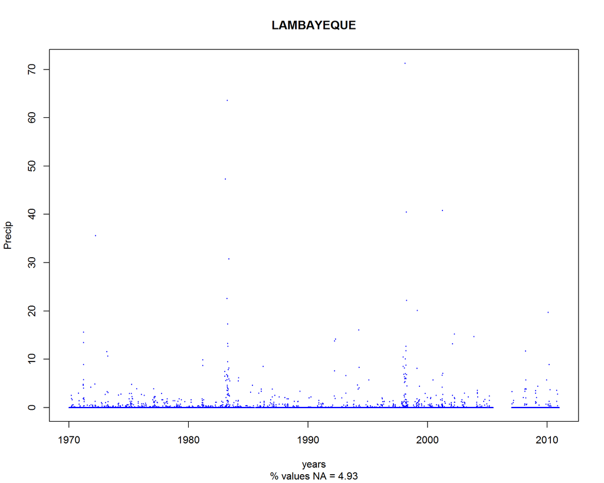

The above chunk of script also calculates the percent of missing data, minimum, maximum and average value for each station and saves it in a table (called “SummaryTimeSeries”). Let’s take a look at the first couple lines of that table here.

```
##              Station Percent_NA  Max Min  Mean    SD
## 1           ASUNCION       4.93 80.2   0 2.225 5.688
## 2 Augusto Weberbauer       0.61 40.5   0 1.791 3.843
## 3            AYLAMBO      80.87 50.1   0 1.754 3.917
## 4         BAMBAMARCA       9.08 51.5   0 2.044 4.379
## 5           CACHACHI       1.47 63.9   0 2.477 5.825
## 6          CAJABAMBA       8.61 66.2   0 2.678 5.712
```

We can repeat the process above for minimum temperature and maximum temperature, simply by changing the first two variables (data and clima.var). Let’s take a look at a sample plot and the data summary table for minimum temperature….

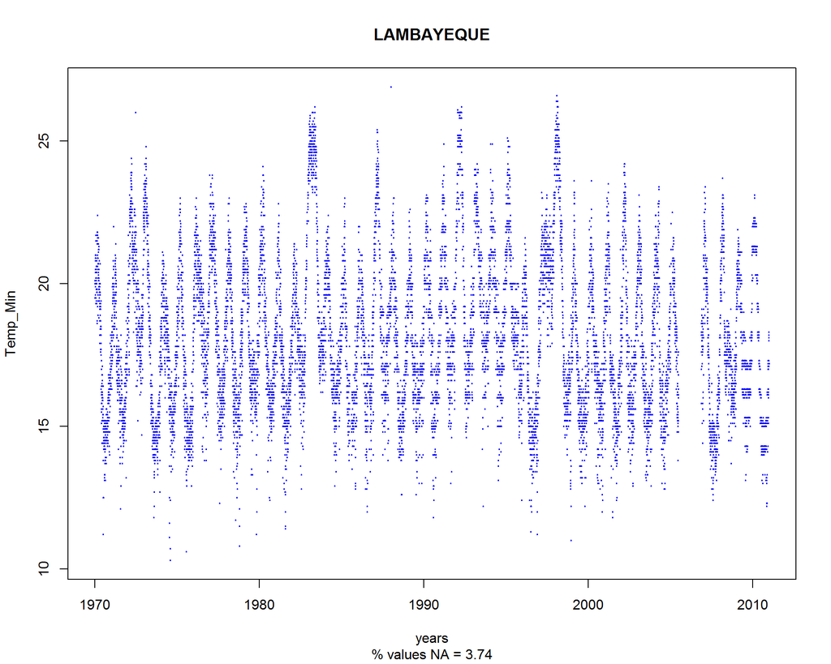

```
##              Station Percent_NA  Max  Min   Mean    SD
## 1           ASUNCION      41.67 16.5  1.2 12.013 1.708
## 2 Augusto Weberbauer       0.41 14.6 -4.3   7.52 3.041
## 3            AYLAMBO      65.87   15    1  9.724 1.676
## 4         BAMBAMARCA          0   16 -5.8  9.684 2.957
## 5           CACHACHI        100 -Inf  Inf    NaN  <NA>
## 6          CAJABAMBA        100 -Inf  Inf    NaN  <NA>
```

… and maximum temperature.

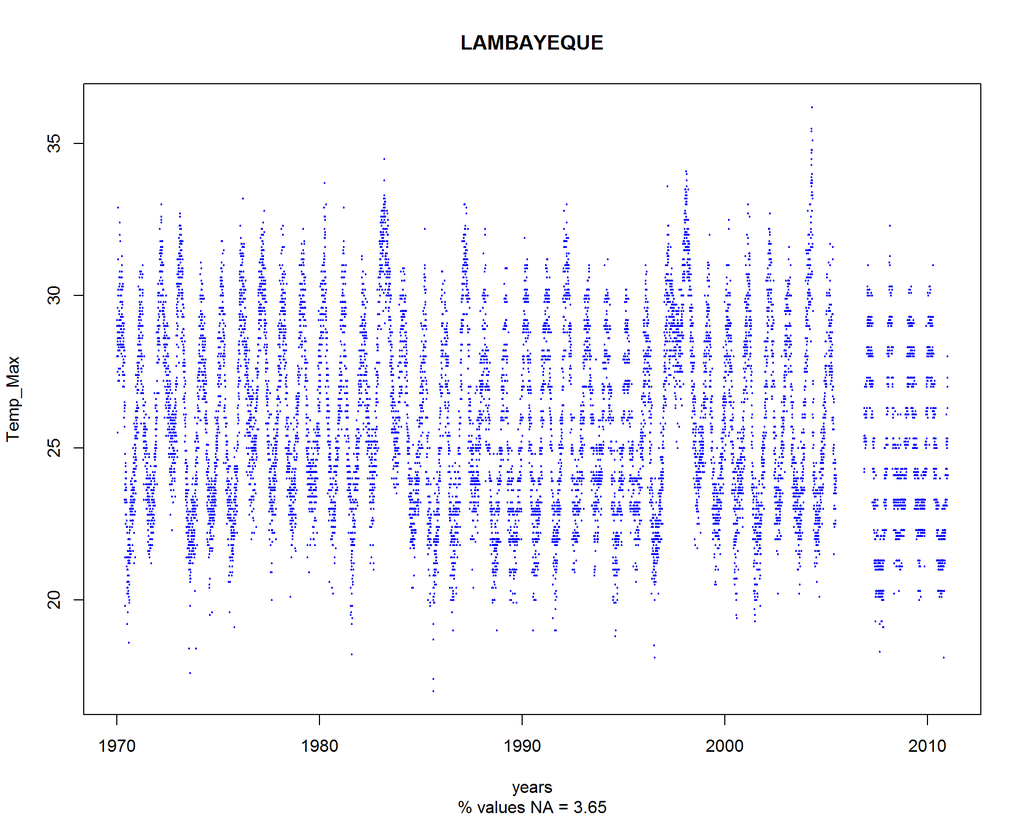

```
##              Station Percent_NA  Max  Min   Mean    SD
## 1           ASUNCION      41.67 31.2 13.4 22.276 2.859
## 2 Augusto Weberbauer       0.41 26.4 13.4 21.562 1.659
## 3            AYLAMBO      65.87 28.8 10.7 21.021 2.466
## 4         BAMBAMARCA          0 26.7   11 19.748 1.972
## 5           CACHACHI        100 -Inf  Inf    NaN  <NA>
## 6          CAJABAMBA        100 -Inf  Inf    NaN  <NA>
```

# 5. Subset your data

Armed with the knowledge and understanding you’ve gained about your data, let’s move on to subsetting your data to a designated period of record, and to the final stations you want to include in the next steps of your analysis.

```r
year1 <- 1970 ##USER-DEFINED first year
year2 <- 2015 ##USER-DEFINED last year

Temp_Min <- subset(Temp_Min, Temp_Min$Anio >= year1) # Subsets data frame for which the year is greater than the previously defined start year
Temp_Min <- subset(Temp_Min, Temp_Min$Anio <= year2) # Selects data frame for which the year is less than the previously defined end year

Temp_Max <- subset(Temp_Max, Temp_Max$Anio >= year1) # Subsets data frame for which the year is greater than the previously defined start year
Temp_Max <- subset(Temp_Max, Temp_Max$Anio <= year2) # Selects data frame for which the year is less than the previously defined end year

Precip <- subset(Precip, Precip$Anio >= year1) # Subsets data frame for which the year is greater than the previously defined start year
Precip <- subset(Precip, Precip$Anio <= year2) # Selects data frame for which the year is less than the previously defined end year
```

Note that at this point in the process, you can also eliminate those stations you’ve identified as too faulty, or with too much missing data, or too far from your study area. Here, for example, we’ll eliminate the station called “Namballe”, because it has over 70% missing data for our selected time frame for both temperature and precipitation and because it’s located very far from our study area.

```r
Precip$NAMBALLE <- NULL
Temp_Max$NAMBALLE <- NULL
Temp_Min$NAMBALLE <- NULL
```

# 6. Identifying and removing errors & extremes

After you’ve familiarized ourselves with your data, the next step is to identify errors and anomalies in your time series. This requires an understanding of what kinds of climate values are appropriate for your study site.

## Eliminate negative precipitation values and all nonnumeric climate measurements

First, let’s eliminate negative precipitation precipitation values, as well as any nonnmeric values in all three climate data sets. Note that these nonnumeric values can be code for something else, depending on how the measurements were taken. In this case, it may be more appropriate to replace these with known numeric values (for example, a “T” in precipitation data may stand for “Traces” and could be replaced with a “0” value).

```r
NewPrecip <- sapply(Precip[,5:ncol(Precip)],as.numeric) # Formats precip data as numeric (which automatically replaces any nonnumeric values with "NA")
neg_number_precip <- length(which(NewPrecip<0)) # Returns number of times a precip value is < 0
NewPrecip[NewPrecip < 0] <- NA # Replaces precip values < 0 with NA
neg_number_precip2 <- length(which(NewPrecip<0)) # Returns number of times a precip value is < 0 after fixing (for purposes of checking work). Should be 0.
Precip <- cbind(Precip[,1:4],NewPrecip) # Re-saves "fixed" precip data as "Precip" R object

Temp_MinNum <- sapply(Temp_Min[,5:ncol(Temp_Min)],as.numeric) # Changes the values in the min Temp data table to numeric format
Temp_Min <- cbind(Temp_Min[,1:4],Temp_MinNum)
Temp_MaxNum <- sapply(Temp_Max[,5:ncol(Temp_Max)],as.numeric) # Changes the values in the min Temp data table to numeric format
Temp_Max <- cbind(Temp_Max[,1:4],Temp_MaxNum)
```

## Identifies and removes user-defined “extreme” climate measurements

Now, let’s define some threshholds to determine what an “extreme” (high or low) measurement would be. You can determine these threshholds from local knowledge or by referring to the plots or statistical summaries we’ve previously created. Note that the threshholds defined below are relevant to our example study site, the Chancay Lambayeque watershed in Peru.

```r
max_Tmin <- 35 ##USER-defined: threshold for reasonable max of Tmin
max_Tmax <- 41 ##USER-defined: threshold for reasonable Tmax max
min_Tmin <- -10.5##USER-defined: threshold for reasonable Tmin min
min_Tmax <- 9 ##USER-defined: threshold for reasonable Tmax min
max_Precip <- 146 ##USER-defined: threshold for reasonable precip max
```

Now, let’s use our dataset for minimum temperature as an example for how to identify and eliminate the values above or below these threshholds. This script identifies these extreme values and saves them to a table exported to your directory for reference; eliminates extreme values in your original dataset, and saves a new extreme-free table of station data to your directory.

```r
Numeric <- Temp_Min[,5:ncol(Temp_Min)] # defines variable

number_below <- length(which(Numeric<min_Tmin)) # Finds the number of times a minimum temperature value falls below the user-defined acceptable minimum for min temperature
number_above <- length(which(Numeric>max_Tmin)) # Finds the number of times a minimum temperature value falls above the user-defined acceptable maximum for min temperature
number_below # Prints the number of extreme low values (for reference, to see in code output)
```

```
## [1] 0
```

```r
number_above # Prints the number of extreme high values (for reference, to see in code output)
```

```
## [1] 9
```

```r
errormatrix <- matrix(data=NA, nrow=ncol(Numeric)*nrow(Numeric),ncol=3) # creates empty error matrix to be filled in in next loop
if(number_below > 0)  # If there are extreme values, loops through station data to select the "extreme" values and saves them in a table
{
  for (c in 1:ncol(Numeric)) # cycles through data table to look for extreme values
  {
    for (r in 1:nrow(Numeric))
    {
      if (!is.na(Numeric[r,c]) && Numeric[r,c] < min_Tmin) # if a value is identified as "extreme", it is saved into the error matrix
      { row <- r + (c-1)*nrow(Numeric)
      names <- colnames(Numeric)
      errormatrix[row,1] <- names[c] # the station in which the extreme value ocurred is saved into the error matrix
      errormatrix[row,2] <- paste(c(Temp_Min[r,2],"-",Temp_Min[r,3],"-",Temp_Min[r,4]),collapse="") # the date on which the extreme value ocurred is saved into the error matrix
      errormatrix[row,3] <- Numeric[r,c] # the value of the extreme value is saved into the error matrix
      }
    }
  }
}
errormatrix3 <- na.omit(errormatrix) # lines in the error matrix which remained empty are eliminated from the table
colnames(errormatrix3) <- c("Station","Date","Value_Extreme Low") # column names for the error matrix are defined

errormatrix <- matrix(data=NA, nrow=ncol(Numeric)*nrow(Numeric),ncol=3) # creates empty error matrix to be filled in in next loop
if(number_above > 0)  ## Same loop/logic as above, but looking for extreme high values
{
  errormatrix <- matrix(data=NA, nrow=ncol(Numeric)*nrow(Numeric),ncol=3)
  for (c in 1:ncol(Numeric))
  {
    for (r in 1:nrow(Numeric))
    {
      if (!is.na(Numeric[r,c]) && Numeric[r,c] > max_Tmin)
      { row <- r + (c-1)*nrow(Numeric)
      names <- colnames(Numeric)
      errormatrix[row,1] <- names[c]
      errormatrix[row,2] <- paste(c(Temp_Min[r,2],"-",Temp_Min[r,3],"-",Temp_Min[r,4]),collapse="")
      errormatrix[row,3] <- Numeric[r,c]
      }
    }
  }

}
errormatrix2 <- na.omit(errormatrix)
colnames(errormatrix2) <- c("Station","Date","Value_Extreme High")

errormatrix_res <- rbind(errormatrix2,errormatrix3) # combines the error matrices for the extreme high values and extreme low values
Numeric[Numeric > max_Tmin] <- NA # replaces the extreme high values in the original data table with NA
Numeric[Numeric < min_Tmin] <- NA # replaces the extreme low values in the original data table with NA
Temp_Min_C <- cbind(Temp_Min[,2:4],Numeric) # formats the final output data table to include the year, month, day columns
setwd(dir)
write.csv(Temp_Min_C, "Table_All_NoExt_Temp_Min.csv") # Saves the intermediate data table (subsetted and without extreme values) in the output directory.
setwd(dir)
write.csv(errormatrix_res, "Temp_Min_Extremes.csv") # Saves the error matrix containing the extreme high and extreme low values in the output directory.
```

Let’s take a look at a sample of the extreme values the script has identified for our minimum temperature dataset.

```
##       Station       Date Value_Extreme High
## 1    ASUNCION  2012-3-25              112.2
## 2     CAYALTI  2014-2-20                212
## 3    CELENDIN  2008-4-10                211
## 4 LA ENCAÑADA  2003-4-12                 92
## 5 LA ENCAÑADA  2005-2-21               1103
## 6   MAGDALENA 2013-12-10                174
```

We can repeat the above process for our maximum temperature dataset. Let’s skip forward and see a sample of the extreme values the script identified in this dataset.

```
##      Station       Date Value_Extreme High
## 1   ASUNCION  2013-6-14                242
## 2   ASUNCION  2013-11-3              210.6
## 3   ASUNCION 2013-12-26                216
## 4 BAMBAMARCA 2011-12-26                177
## 5  CONTUMAZA  2013-6-25                206
## 6 EL ESPINAL 2011-12-14                286
```

The last dataset needing some cleaning up is precipitation; because we don’t have a minimum threshhold for precipitation (we’ve already removed those observations below 0), the process for identifying and removing extremes is slightly different. Let’s see.

```r
Numeric <- Precip[,5:ncol(Precip)]

number_above <- length(which(Numeric>max_Precip))
number_above # the number of values above the threshhold
```

```
## [1] 17
```

```r
errormatrix <- matrix(data=NA, nrow=ncol(Numeric)*nrow(Numeric),ncol=3) # creates empty error matrix to be filled in in next loop
if(number_above > 0)  ## Loops through station data to select the "extreme" values and saves them in a table
  {
  for (c in 1:ncol(Numeric))
  {
    for (r in 1:nrow(Numeric))
    {
      if (!is.na(Numeric[r,c]) && Numeric[r,c] > max_Precip)
      { row <- r + (c-1)*nrow(Numeric)
      names <- colnames(Numeric)
      errormatrix[row,1] <- names[c]
      errormatrix[row,2] <- paste(c(Precip[r,2],"-",Precip[r,3],"-",Precip[r,4]),collapse="")
      errormatrix[row,3] <- Numeric[r,c]
      }
    }
  }

}
errormatrix2 <- na.omit(errormatrix)
colnames(errormatrix2) <- c("Station","Date","Value")
setwd(dir)
write.csv(errormatrix2, "Precip_Extremes.csv")

Numeric[Numeric > max_Precip] <- NA #Replaces extreme values with NA
Precip_C <- cbind(Precip[,2:4],Numeric)
setwd(dir)
write.csv(Precip_C, "Table_All_NoExt_Precip.csv",row.names = F)
```

Let’s see what extreme precipitation values the script has identified (and removed from the dataset).

```
##     Station       Date Value
## 1     CHOTA 1980-10-17 160.5
## 2 CONTUMAZA   1979-3-5   387
## 3 CONTUMAZA   1979-3-7   160
## 4 CONTUMAZA  1979-3-19   280
## 5 CONTUMAZA  1979-3-20   347
## 6 CONTUMAZA  1979-3-24   251
```

This process may be iterative as you adjust the minimum and maximum threshholds for your climate data. Note that there may exist other anomalies and errors in your dataset, which would require some more detailed coding and more local knowledge of climate conditions. These additional anomalies may include: high precipitation values in the dry season, non-sequential temperature or precipitaiton observations, etc.

## Identifies errors in which minimum daily temperature is greater than maximum daily temperature

Finally, we want to identify those data values that correspond to a very specific error in your dataset: dates in which the recorded maximum temperature is less than the recorded minimum temperature. This script will identify the dates in which this occurs and save the dates as well as the observations causing this error in a table exported to your directory.

```r
Temp_Min <- Temp_Min_C #renames the variables with "corrected" dataset
Temp_Max <- Temp_Max_C #renames the variables with "corrected" dataset

temp_stations <- intersect(colnames(Temp_Min),colnames(Temp_Max)) # creates variable containing the names of the stations that have both min and max temperature measurements
Temp_Min <- subset(Temp_Min, select=temp_stations) # subsets the minimum temperature data table to select only those columns (ie stations) that have both min and max temperature measurements
Temp_Max <- subset(Temp_Max, select=temp_stations) # subsets the maximum temperature data table to select only those columns (ie stations) that have both min and max temperature measurements

errormatrix <- matrix(data=NA, nrow=ncol(Temp_Min)*nrow(Temp_Min),ncol=4) # sets up empty matrix to be filled in with the errors
colnames(errormatrix) <- c("Station","Date","Temp_Min","Temp_Max") # names the column of this error matrix

for (c in 1:ncol(Temp_Min)) # cycles through the columns of the data table (to look for errors)
{
  for (r in 1:nrow(Temp_Min)) # cycles through teh rows of each column in the data table (to look for errors)
  { if (!is.na(as.numeric(Temp_Min[r,c])) && !is.na(as.numeric(Temp_Max[r,c]))) # only looks for errors if both temp_min and temp_max have a measurement for that timestep
  {
    if (as.numeric(Temp_Min[r,c]) > as.numeric(Temp_Max[r,c])) # selects the row/column in which minimum temperature is greater than maximum temperature for a timestep
    { row <- r + (c-4)*nrow(Temp_Min)
    errormatrix[row,1] <- colnames(Temp_Max[c]) # saves the station name in which this error ocurrs in the error matrix
    errormatrix[row,2] <- paste(c(Temp_Max[r,1],"-",Temp_Max[r,2],"-",Temp_Max[r,3]),collapse="") # saves the date on which this error ocurrs in the error matrix
    errormatrix[row,3] <- Temp_Min[r,c] # saves the minimum temperature value which caused this error in the error matrix
    errormatrix[row,4] <- Temp_Max[r,c] # saves the maximum temperature value which caused this error in the error matrix
    }
  }
  }
}

errormatrix2 <- na.omit(errormatrix) # removes empty lines from the matrix
write.csv(errormatrix2, "Temp_Errors.csv") # saves the error matrix as a csv table in the output directory
```

Let’s take a look at the errors the script has identified.

```
##             Station       Date Temp_Min Temp_Max
## 1           CAYALTI 2012-11-21     27.8     27.6
## 2         FERREÑAFE   2007-4-2       25     24.8
## 3     GRANJA PORCON   1975-3-7     15.2     14.2
## 4     GRANJA PORCON   1975-3-8     15.4     14.1
## 5     GRANJA PORCON  1975-3-11     15.3       12
## 6     GRANJA PORCON  1975-3-13     21.2     15.4
## 7     GRANJA PORCON  1975-3-15     21.2     16.7
## 8     GRANJA PORCON  1975-3-19     18.1       18
## 9              JAEN  2008-12-2       29     27.8
## 10 JAYANCA(LA VIÑA)  2010-4-19     32.4       18
## 11            LLAPA   1987-2-7     21.8     18.7
## 12            LLAPA   1987-2-9     21.2       19
## 13            LLAPA  1987-2-11       28     18.2
## 14            LLAPA  1987-2-17       28     18.4
## 15            LLAPA  1987-2-18     18.2     17.4
## 16            LLAPA  1987-2-19       27     19.4
## 17            LLAPA  1987-2-20     30.4     21.8
## 18            LLAPA  1987-2-21       30     19.6
## 19            LLAPA  1987-2-22       24       21
## 20        MAGDALENA   2012-4-2     28.6       28
```

Because these errors may have been caused by a variety of reasons (human error when recording observations, a glitch in recording equipment, etc), you will have to manually navigate to those values in your original dataset and fix them as you see most appropriate.

# 7. Filling in missing data

Once you have acquainted yourself with your data and eliminated any clear extreme/error values within your datasets, you will still need to fill in missing data. This workflow is described in detail at the following [link](https://seiwater.github.io/2016/09/15/Filling-Missing-Data-in-Climatological-Time-Series.html).

# Conclusions and next steps

And with that, we conclude this script covering how to conduct some initial analyses of climatological time series. Note that there exist other methods to identify and correct a time series of climate data; the process we’ve introduced here serves as an initial step in this process. Potential future steps include further refining and correcting your time series before filling in missing data. Further applications include preparing climate input series for a WEAP model.